# BI transcriptome all factors

#### Top 30 genes - for a complete model without contrasts, the picture is not very bright, but there is an interesting cluster of genes that decrease in platinum-resistant ones, while E1A cancels this effect.

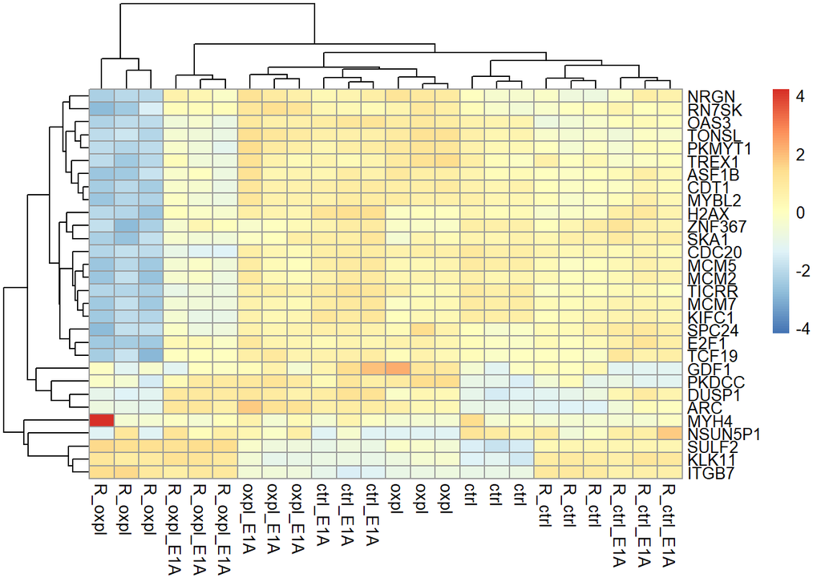

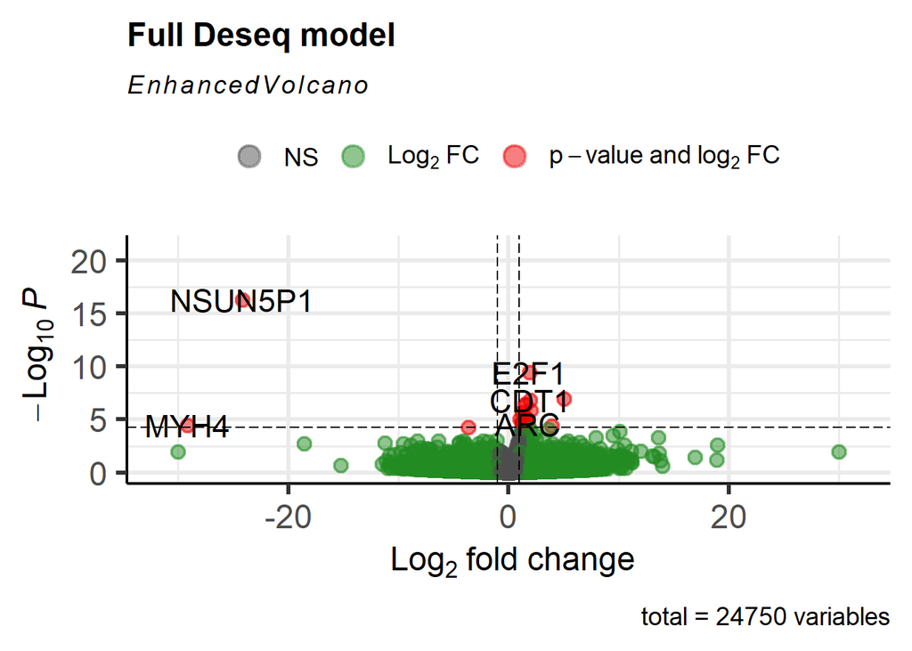

```r
EnhancedVolcano(results,
    lab = rownames(results),
    x = 'log2FoldChange',
    y = 'pvalue',
    pCutoffCol = "padj",
    title = 'Full Deseq model',
    FCcutoff = 1, pCutoff = 0.05,
    pointSize = 3.0,
    labSize = 6.0)
```

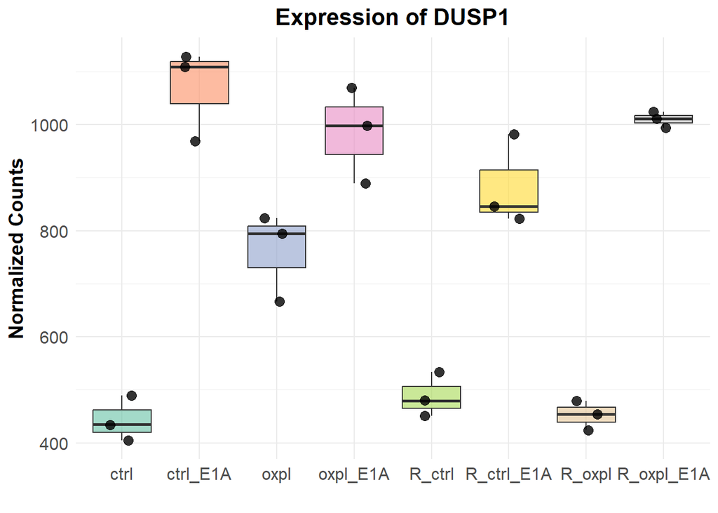

```r
markers <- c("DUSP1", "NSUN5P1", "RN7SK", "NDUFB7", "NDUFB5", "NDUFA2","AKR1C2","AKR1C3","AHR","CDKN1C", "GPX4")

# Checking which genes are really there
present <- markers[markers %in% rownames(dds)]
if(length(present) == 0) stop("Not a single marker was found in dds")
gene <- present[1]

ge <- plotCounts(dds, gene, intgroup = "stat", returnData=TRUE)
ggplot(ge, aes(x = stat, y = count, fill = stat)) +
  geom_boxplot(outlier.shape = NA, alpha = 0.6) +   # boxplot without standard emissions
  geom_jitter(width = 0.2, size = 3, alpha = 0.8) + # points with a small spread on the X-axis
  scale_fill_brewer(palette = "Set2") +             # a beautiful palette of colors
  labs(title = paste("Expression of", gene),
       x = "",
       y = "Normalized Counts") +
  theme_minimal() +
  theme(legend.position = "none",
        axis.text = element_text(size = 12),
        axis.title = element_text(size = 14, face = "bold"),
        plot.title = element_text(size = 16, face = "bold", hjust = 0.5))
```

Functional analysis using the deseq stat metric:

```r
res_e1a <- results
gene_stat <- res_e1a$stat
names(gene_stat) <- rownames(res_e1a)
gene_stat <- na.omit(gene_stat)
gene_stat <- sort(gene_stat, decreasing = TRUE)

gene_list_entrez_stat <- gene_stat
mapping <- mapIds(org.Hs.eg.db,
                 keys = names(gene_stat),
                 column = "ENTREZID",
                 keytype = "SYMBOL",
                 multiVals = "first")
names(gene_list_entrez_stat) <- mapping

gene_list_entrez_stat <- na.omit(gene_list_entrez_stat)
gene_list_entrez_stat <- gene_list_entrez_stat[!is.na(names(gene_list_entrez_stat))]
```

```r
#по stat
gse_GO <- gseGO(geneList=gene_stat,
             ont ="ALL",
             keyType = "SYMBOL",
             minGSSize = 3,
             maxGSSize = 800,
             pvalueCutoff = 0.05,
             verbose = TRUE,
             OrgDb = org.Hs.eg.db,
             pAdjustMethod = "BH")
```

```
## using 'fgsea' for GSEA analysis, please cite Korotkevich et al (2019).
```

```
## preparing geneSet collections...
```

```
## GSEA analysis...
```

```
## leading edge analysis...
```

```
## done...
```

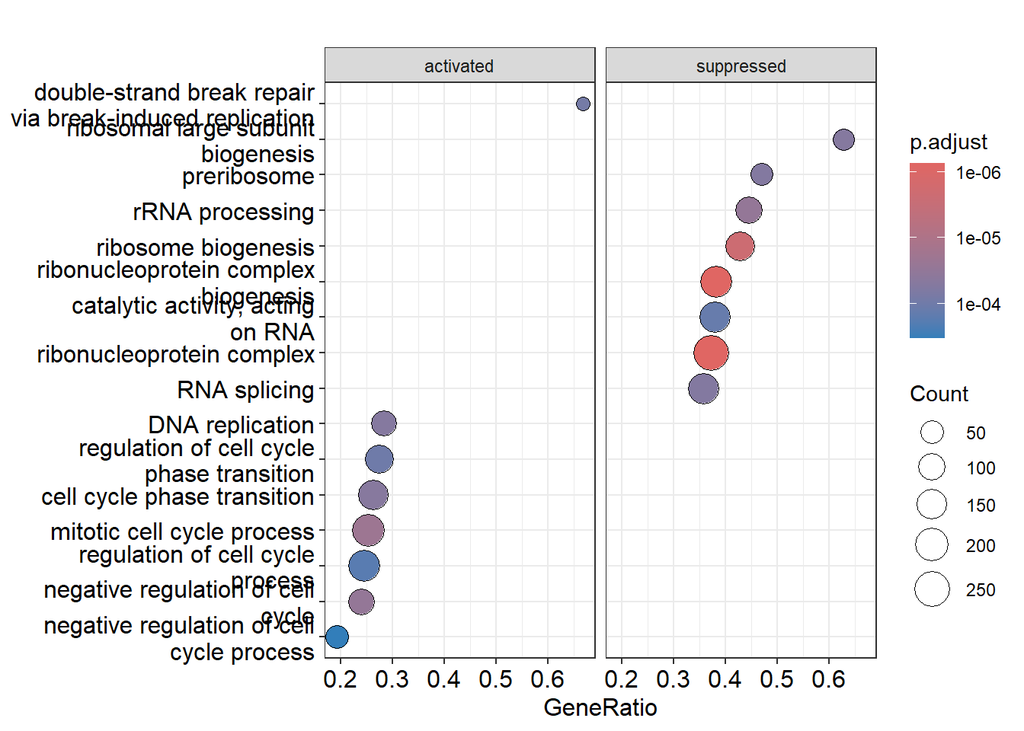

```r
dotplot(gse_GO, showCategory=8, split=".sign") + facet_grid(.~.sign)
```

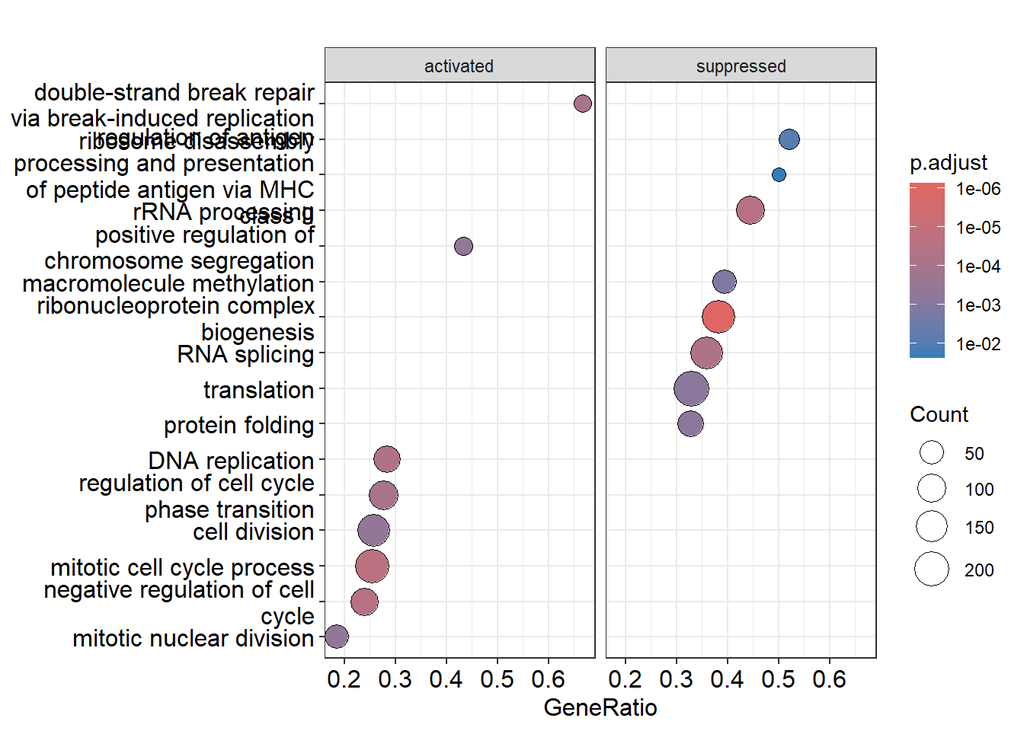

```r
simplified_result <- clusterProfiler::simplify(gse_GO,
                                               cutoff = 0.7,
                                               by = "p.adjust",
                                               select_fun = min)
dotplot(simplified_result, showCategory = 8, split = ".sign") + facet_grid(. ~ .sign)
```

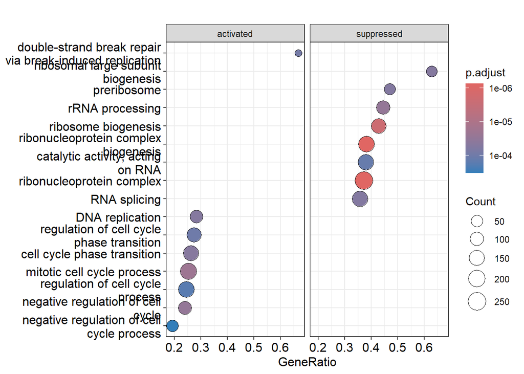

```r
p <- dotplot(gse_GO, showCategory=8, split=".sign") + facet_grid(.~.sign)
p
```

```r
ggsave("gsea_go_all_dotplot.png", plot = p, width = 10, height = 12, dpi = 300)
```

```r
#по stat
gsea_kegg <- gseKEGG(
    geneList = gene_list_entrez_stat,
    organism = "hsa",  ,
    keyType = "ncbi-geneid",
    pvalueCutoff = 0.05,
    pAdjustMethod = "BH"
)
```

```
## Reading KEGG annotation online: "https://rest.kegg.jp/link/hsa/pathway"...
```

```
## Reading KEGG annotation online: "https://rest.kegg.jp/list/pathway/hsa"...
```

```
## Reading KEGG annotation online: "https://rest.kegg.jp/conv/ncbi-geneid/hsa"...
```

```
## using 'fgsea' for GSEA analysis, please cite Korotkevich et al (2019).
```

```
## preparing geneSet collections...
```

```
## GSEA analysis...
```

```
## leading edge analysis...
```

```
## done...
```

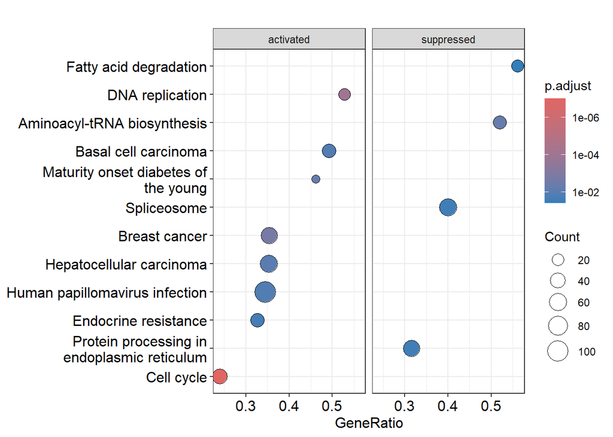

```r
gsea_kegg <- setReadable(gsea_kegg, 'org.Hs.eg.db', keyType = "ENTREZID")

p <- dotplot(gsea_kegg, showCategory=8, split=".sign") + facet_grid(.~.sign)
p
```

```r
ggsave("gsea_kegg_dotplot.png", plot = p, width = 10, height = 12, dpi = 300)
```

Functional analysis - enrichment by transcription factors

```r
library(tftargets)
str(TRED)
```

```
## List of 133
##  $ PAX1  : chr [1:6] "5156" "7428" "9356" "9376" ...
##  $ EGR3  : chr [1:3] "969" "6692" "7161"
##  $ EGR2  : chr [1:9] "355" "682" "2194" "3199" ...
##  $ E2F-1 : chr [1:671] "16" "19" "100" "101" ...
##  $ E2F-2 : chr [1:221] "120" "272" "314" "638" ...
##  $ E2F-4 : chr [1:278] "19" "58" "60" "104" ...
##  $ SP1   : chr [1:332] "12" "32" "100" "118" ...
##  $ TFAP2A: chr [1:320] "12" "43" "118" "128" ...
##  $ TP53  : chr [1:286] "174" "207" "220" "268" ...
##  $ E2F-3 : chr [1:7] "5054" "5329" "7161" "8318" ...
##  $ EGR1  : chr [1:102] "20" "43" "231" "240" ...
##  $ c-Myc : chr [1:783] "34" "43" "50" "51" ...
##  $ USF2  : chr [1:84] "19" "31" "213" "324" ...
##  $ USF1  : chr [1:112] "19" "31" "151" "213" ...
```

[output cut: 86 more lines]

```r
#TRED$TP53

gmt_file <- "TRED_db.gmt"
file_conn <- file(gmt_file, "w")

for (tf_name in names(TRED)) {
  target_genes <- TRED[[tf_name]]
  # Removing possible NA and empty values
  target_genes <- target_genes[!is.na(target_genes) & target_genes != ""]
  if (length(target_genes) == 0) next

  gmt_line <- paste(
    tf_name,                  # The term (TF name)
    "TRED_target_genes",      # description (not used, but needed for GMT format)
    paste(target_genes, collapse = "\t"),  # tabulated genes
    sep = "\t"
  )
  writeLines(gmt_line, file_conn)
}
close(file_conn)

library(clusterProfiler)
library(tidyverse)
gmt_to_TERM2GENE <- function(gmt_file) {
  readLines(gmt_file) %>%
    strsplit("\t") %>%
    lapply(function(x) {
      term <- x[1]
      genes <- x[-c(1, 2)]
      data.frame(term = term, gene = genes)
    }) %>%
    bind_rows()
}
TERM2GENE <- gmt_to_TERM2GENE("TRED_db.gmt")


head(TERM2GENE)
```

```
##   term   gene
## 1 PAX1   5156
## 2 PAX1   7428
## 3 PAX1   9356
## 4 PAX1   9376
## 5 PAX1  55210
## 6 PAX1 118856
```

```r
gsea_TRED <- GSEA(
  geneList = gene_list_entrez_stat,
  pvalueCutoff = 0.05,
  pAdjustMethod = "none",
  TERM2GENE = TERM2GENE
)
```

```
## using 'fgsea' for GSEA analysis, please cite Korotkevich et al (2019).
##
## preparing geneSet collections...
## GSEA analysis...
```

```
## leading edge analysis...
## done...
```

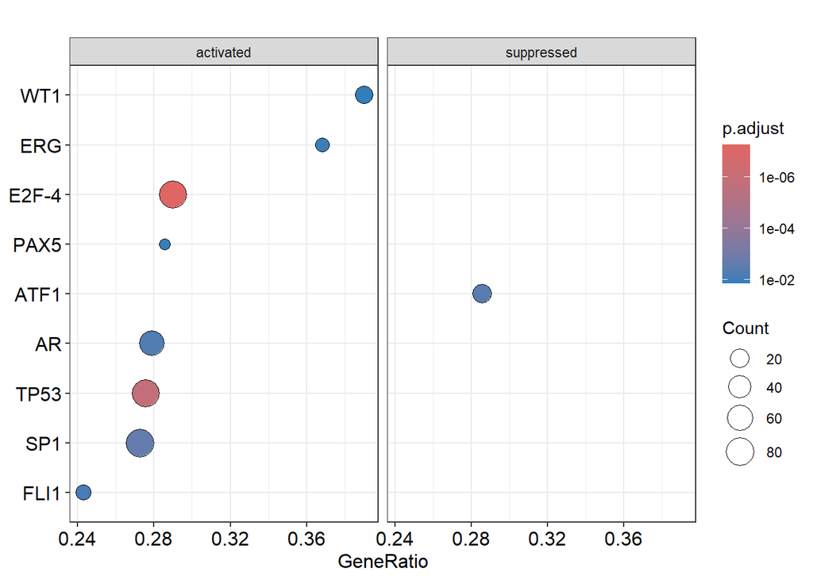

```r
gsea_TRED <- setReadable(gsea_TRED, 'org.Hs.eg.db', keyType = "ENTREZID")
# Visualization
dotplot(gsea_TRED, showCategory=8, split=".sign") + facet_grid(.~.sign)
```

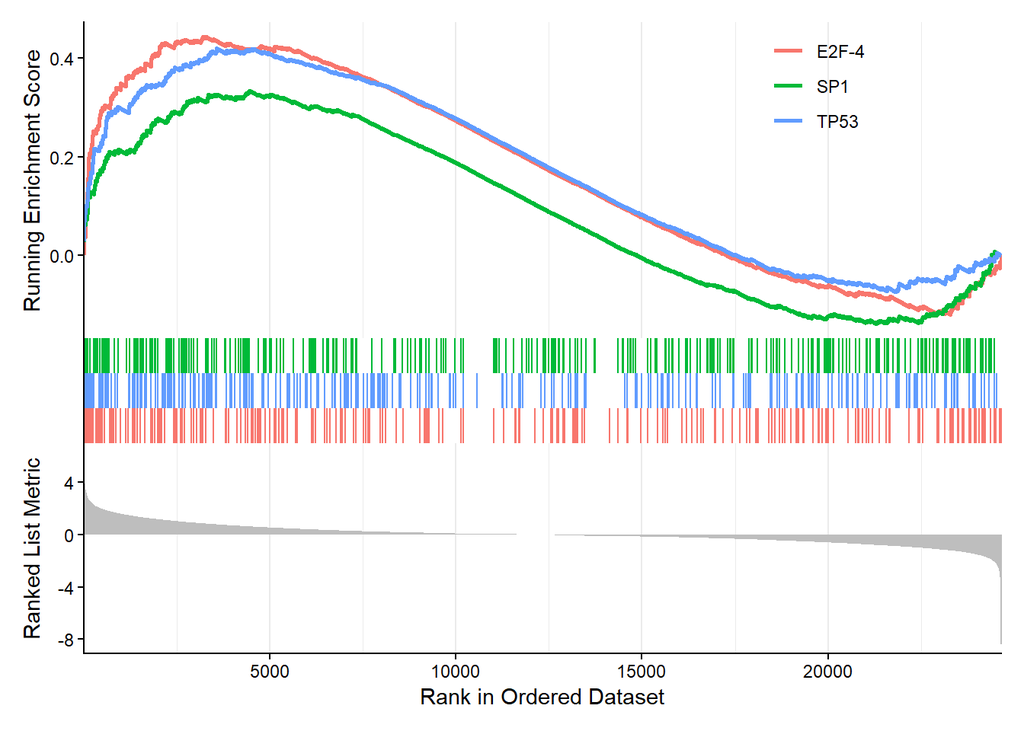

```r
gseaplot2(gsea_TRED, geneSetID = 1:3)
```

```r
DEG_PT <- as.data.frame(results)
```

## Moving on to subtask 3

#### A comparison of chemosensitization of sensitive and resistant cells with E1A expression is a complete DESEQ model that takes into account all the factors

```r
resultsNames(dds)
```

```
## [1] "Intercept"
## [2] "e1a_status_positive_vs_negative"
## [3] "condition_oxpl_vs_ctrl"
## [4] "cell_line_HCT116_oxpl_R_vs_HCT116"
## [5] "e1a_statuspositive.conditionoxpl"
## [6] "e1a_statuspositive.cell_lineHCT116_oxpl_R"
## [7] "conditionoxpl.cell_lineHCT116_oxpl_R"
## [8] "e1a_statuspositive.conditionoxpl.cell_lineHCT116_oxpl_R"
```

~ e1a_status * condition * cell_line or e1a_status**positive** .condition**oxpl**.cell_line**HCT116_oxpl_R**

that is, each factoring level is based on its reference value

```r
res_int <- results(dds, name = "e1a_statuspositive.conditionoxpl.cell_lineHCT116_oxpl_R")


res_int <- res_int[order(res_int$pvalue), ]
summary(res_int)
```

```
##
## out of 24750 with nonzero total read count
## adjusted p-value < 0.1
## LFC > 0 (up)       : 26, 0.11%
## LFC < 0 (down)     : 3, 0.012%
## outliers [1]       : 27, 0.11%
## low counts [2]     : 6238, 25%
## (mean count < 1)
## [1] see 'cooksCutoff' argument of ?results
## [2] see 'independentFiltering' argument of ?results
```

```r
sig_genes <- res_int[!is.na(res_int$padj) & res_int$padj < 0.05 & abs(res_int$log2FoldChange) > 1, ]

# If there are none, use padj < 0.1
if (nrow(sig_genes) == 0) {
  sig_genes <- res_int[!is.na(res_int$padj) & res_int$padj < 0.1, ]
  cat("Using padj < 0.1 (", nrow(sig_genes), "genes)\n")
} else {
  cat("Using padj < 0.05 (", nrow(sig_genes), "genes)\n")
}
```

```
## Using padj < 0.05 ( 20 genes)
```

```r
df_sig <- data.frame(
  Gene = rownames(sig_genes),
  log2FoldChange = sig_genes$log2FoldChange,
  pvalue = sig_genes$pvalue,
  padj = sig_genes$padj,
  Direction = ifelse(sig_genes$log2FoldChange > 0, "up", "down")
)

# Sort, for example, by descending absolute log2FC
df_sig <- df_sig[order(abs(df_sig$log2FoldChange), decreasing = TRUE), ]

df_dir <- df_sig[order(df_sig$Direction, df_sig$Gene), ]
df_dir$log2FC_rounded <- round(df_dir$log2FoldChange, 2)

cat(paste0(df_dir$Gene, " (", df_dir$Direction, ") log2FC = ", df_dir$log2FC_rounded, collapse = "\n"))
```

```
## ITGB7 (down) log2FC = -3.66
## MYH4 (down) log2FC = -29.13
## NSUN5P1 (down) log2FC = -24.17
## ARC (up) log2FC = 1.76
## CDT1 (up) log2FC = 1.95
## DUSP1 (up) log2FC = 1.2
## E2F1 (up) log2FC = 1.91
## H2AX (up) log2FC = 1.54
## KIFC1 (up) log2FC = 1.19
## KLK11 (up) log2FC = 3.91
## MCM5 (up) log2FC = 1.49
## MCM7 (up) log2FC = 1.01
## MYBL2 (up) log2FC = 1.48
## NRGN (up) log2FC = 1.64
## OAS3 (up) log2FC = 1.2
## PKDCC (up) log2FC = 5.03
## SULF2 (up) log2FC = 1.44
## TICRR (up) log2FC = 1.51
## TONSL (up) log2FC = 1.23
## TREX1 (up) log2FC = 2
```

```r
cat(paste0(df_dir$log2FoldChange, collapse = "\n"))
```

```
## -3.66257269535722
## -29.1267453195793
## -24.1747585992974
## 1.75827746198678
## 1.95257655035016
## 1.20110596115644
## 1.90752554982246
## 1.5358528493285
## 1.19480757774833
## 3.90794033231805
## 1.49154042814016
## 1.01494201229467
## 1.47650542376739
## 1.63969758808586
## 1.20008305532215
## 5.02838369617327
## 1.44063882332512
## 1.51256429243219
## 1.2267654400373
## 2.00487037829477
```

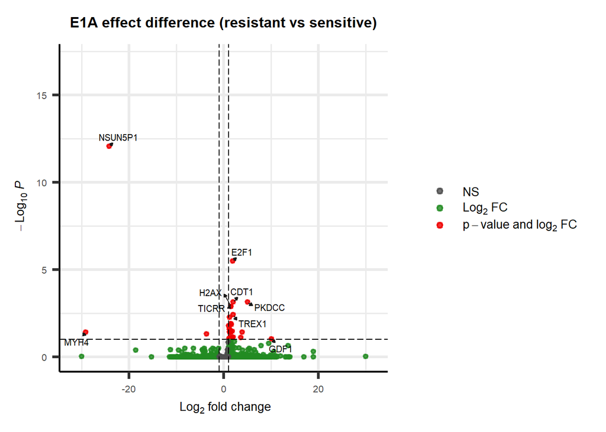

```r
p <- EnhancedVolcano(res_int,
                     lab = rownames(res_int),
                     x = 'log2FoldChange',
                     y = 'padj',
                     title = 'E1A effect difference (resistant vs sensitive)',
                     subtitle = NULL,
                     caption = NULL,
                     FCcutoff = 1,
                     pCutoff = 0.1,
                     labSize = 2.6,
                     axisLabSize = 8,
                     titleLabSize = 14,
                     subtitleLabSize = 8,
                     captionLabSize = 8,
                     colAlpha = 0.8,
                     pointSize = 1.0,
                     legendLabSize = 10,
                     legendIconSize = 3.0,
                     legendPosition = "right",
                     drawConnectors = TRUE)

p <- p +
  theme(text = element_text(size = 10),
        plot.title = element_text(hjust = 0.5, size = 12),
        axis.title = element_text(size = 10),
        axis.text = element_text(size = 10)) +
  guides(color = guide_legend(override.aes = list(size = 1.5))) +
  theme(aspect.ratio = 1)

print(p)
```

```r
ggsave("volcano_plot.png", plot = p, width = 8, height = 8, dpi = 600)
```

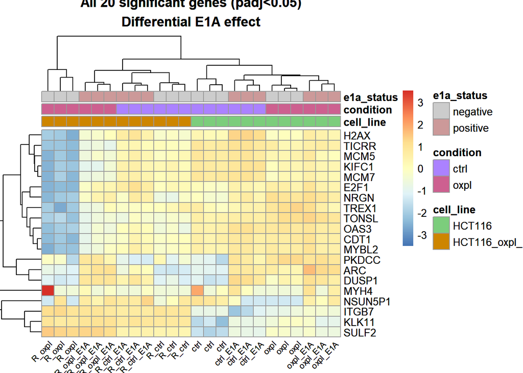

```r
#We take all significant genes (padj<0.1)
sig_all <- res_int[!is.na(res_int$padj) & res_int$padj < 0.05, ]
sig_all <- sig_all[order(abs(sig_all$log2FoldChange), decreasing = TRUE), ]
genes <- rownames(sig_all)

# Expression matrix - DO NOT CHANGE column names
norm_counts <- counts(dds, normalized = TRUE)
mat_log <- log2(norm_counts[genes, ] + 1)   # column names = rownames(colData(dds))

anno_df <- data.frame(
  cell_line = colData(dds)$cell_line,
  condition = colData(dds)$condition,
  e1a_status = colData(dds)$e1a_status,
  row.names = rownames(colData(dds))
)

# We get the levels from announce (they should already be correct)
lv_cell <- levels(anno_df$cell_line)
lv_cond <- levels(anno_df$condition)
lv_e1a <- levels(anno_df$e1a_status)

# We set the colors in the same order as the levels.
ann_colors <- list(
  cell_line = setNames(c("#7CCD7C", "#CD8500"), lv_cell),
  condition = setNames(c("#AB82FF", "#CD6090"), lv_cond),
  e1a_status = setNames(c("#CCCCCC", "#CC9999"), lv_e1a)
)
# Make sure that the length of the colors matches the length of the levels.
stopifnot(length(lv_cell) == length(ann_colors$cell_line))
stopifnot(length(lv_cond) == length(ann_colors$condition))
stopifnot(length(lv_e1a) == length(ann_colors$e1a_status))

# We build a heat map by setting column labels via labels_col
heatmap <- pheatmap(mat_log,
         scale = "row",
         annotation_col = anno_df,
         annotation_colors = ann_colors,
         labels_col = colData(dds)$stat,
         angle_col = 45,
         fontsize_col = 8,
         cellheight = 10,
         cellwidth = 12,
         main = paste("All", length(genes), "significant genes (padj<0.05)\nDifferential E1A effect"))

print(heatmap)
```

```r
ggsave("heatmap.png", plot = heatmap, width = 14, height = 10, dpi = 300)
```

```r
total_genes <- sum(!is.na(res_int$padj))  # genes after low counts filtering (24750)
sig_genes <- sum(res_int$padj < 0.05, na.rm = TRUE)
up_genes <- sum(res_int$log2FoldChange > 0 & res_int$padj < 0.05, na.rm = TRUE)
down_genes <- sum(res_int$log2FoldChange < 0 & res_int$padj < 0.05, na.rm = TRUE)

cat("=== Quantitative metrics for triple interaction ===\n")
```

```
## === Quantitative metrics for triple interaction ===
```

```r
cat("Total genes tested:", total_genes, "\n")
```

```
## Total genes tested: 18485
```

```r
cat("Significant genes (padj < 0.05):", sig_genes, "\n")
```

```
## Significant genes (padj < 0.05): 20
```

```r
cat("  Up (LFC > 0):", up_genes, "\n")
```

```
##   Up (LFC > 0): 17
```

```r
cat("  Down (LFC < 0):", down_genes, "\n")
```

```
##   Down (LFC < 0): 3
```

```r
# 1. We take statistics from the triple interaction
geneList <- res_int$stat
names(geneList) <- rownames(res_int)
geneList <- geneList[!is.na(geneList)]

# 2. Adding micro-noise to break ties (optional, but neat)
set.seed(123)
geneList <- geneList + rnorm(length(geneList), 0, 1e-8)

# 3. Sort in descending order
geneList <- sort(geneList, decreasing = TRUE)

# 4. Converting characters to Entrez ID
geneList_entrez <- geneList
names(geneList_entrez) <- mapIds(org.Hs.eg.db,
                                 keys = names(geneList),
                                 column = "ENTREZID",
                                 keytype = "SYMBOL",
                                 multiVals = "first")
# Deleting NA
geneList_entrez <- geneList_entrez[!is.na(geneList_entrez)]
# Making sure that the names are also not NA
geneList_entrez <- geneList_entrez[!is.na(names(geneList_entrez))]

# 5.Sorting again (conversion could have changed the order)
geneList_entrez <- sort(geneList_entrez, decreasing = TRUE)

# 6.Launching GSEA GO
gse_go <- gseGO(geneList = geneList_entrez,
                OrgDb = org.Hs.eg.db,
                ont = "ALL",
                keyType = "ENTREZID",
                minGSSize = 10,
                maxGSSize = 500,
                pvalueCutoff = 0.05,
                verbose = TRUE)
```

```
## using 'fgsea' for GSEA analysis, please cite Korotkevich et al (2019).
```

```
## preparing geneSet collections...
```

```
## GSEA analysis...
```

```
## leading edge analysis...
```

```
## done...
```

```r
gse_bp <- gseGO(geneList = geneList_entrez,
                OrgDb = org.Hs.eg.db,
                ont = "BP",
                keyType = "ENTREZID",
                minGSSize = 10,
                maxGSSize = 500,
                pvalueCutoff = 0.05,
                verbose = TRUE)
```

```
## using 'fgsea' for GSEA analysis, please cite Korotkevich et al (2019).
```

```
## preparing geneSet collections...
```

```
## GSEA analysis...
```

```
## leading edge analysis...
```

```
## done...
```

```r
gse_cc <- gseGO(geneList = geneList_entrez,
                OrgDb = org.Hs.eg.db,
                ont = "CC",
                keyType = "ENTREZID",
                minGSSize = 10,
                maxGSSize = 500,
                pvalueCutoff = 0.05,
                verbose = TRUE)
```

```
## using 'fgsea' for GSEA analysis, please cite Korotkevich et al (2019).
```

```
## preparing geneSet collections...
```

```
## GSEA analysis...
```

```
## leading edge analysis...
```

```
## done...
```

```r
gse_mf <- gseGO(geneList = geneList_entrez,
                OrgDb = org.Hs.eg.db,
                ont = "MF",
                keyType = "ENTREZID",
                minGSSize = 10,
                maxGSSize = 500,
                pvalueCutoff = 0.05,
                verbose = TRUE)
```

```
## using 'fgsea' for GSEA analysis, please cite Korotkevich et al (2019).
```

```
## preparing geneSet collections...
```

```
## GSEA analysis...
```

```
## leading edge analysis...
```

```
## done...
```

```
## ALL: 170 activated, 67 suppressed
```

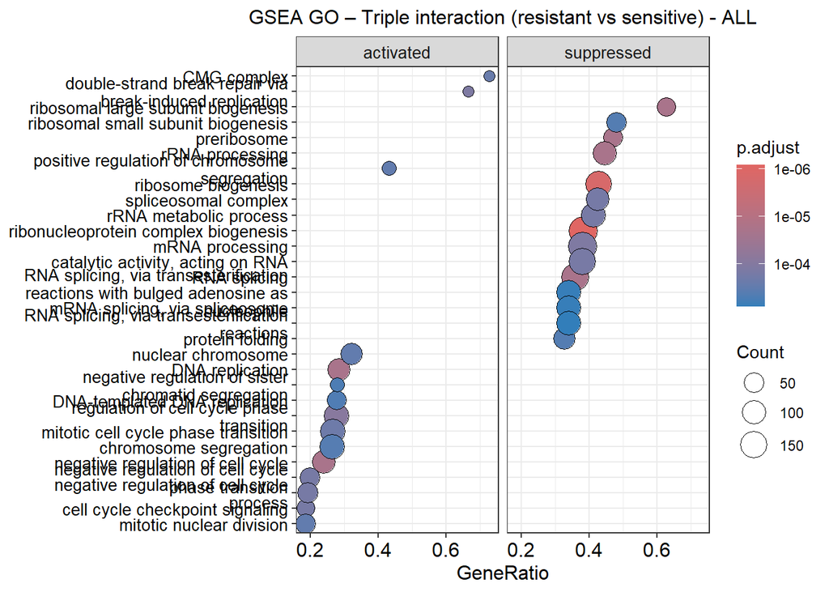

```r
plot_gsea_split <- function(gsea_obj, ont_name, show = 10, width = 10, height = 9) {
  if (is.null(gsea_obj) || nrow(gsea_obj) == 0) {
    message("No significant terms for ", ont_name)
    return(NULL)
  }

  n_pos <- sum(gsea_obj$NES > 0)
  n_neg <- sum(gsea_obj$NES < 0)
  message(ont_name, ": ", n_pos, " activated, ", n_neg, " suppressed")

  p <- dotplot(gsea_obj, showCategory = show, split = ".sign", label_format = 40) +
         facet_grid(. ~ .sign, drop = FALSE) +
         ggtitle(paste("GSEA GO – Triple interaction (resistant vs sensitive) -", ont_name)) +
         theme(plot.title = element_text(hjust = 0.5, size = 12),
               axis.text.y = element_text(size = 10),
               strip.text = element_text(size = 10))

  print(p)
  ggsave(paste0("gsea_go_triple_", tolower(ont_name), ".png"), plot = p, width = width, height = height, dpi = 600)
}

plot_gsea_split(gse_go, "ALL", show = 15)
```

```
## BP: 147 activated, 34 suppressed
```

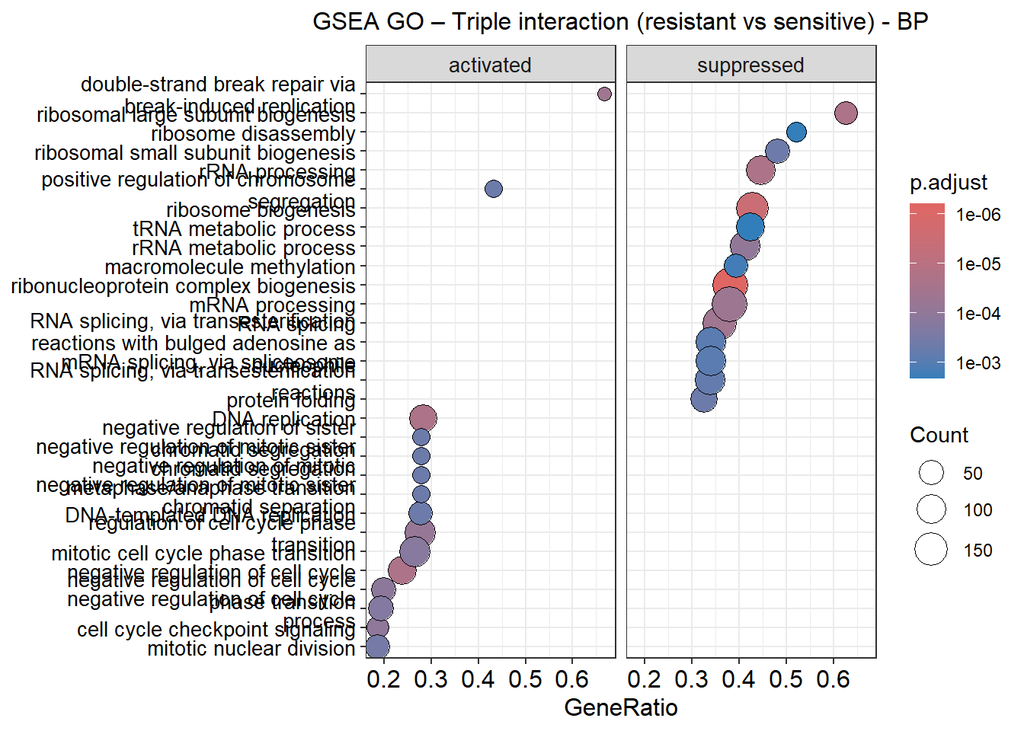

```r
plot_gsea_split(gse_bp, "BP", show = 15)
```

```
## CC: 19 activated, 16 suppressed
```

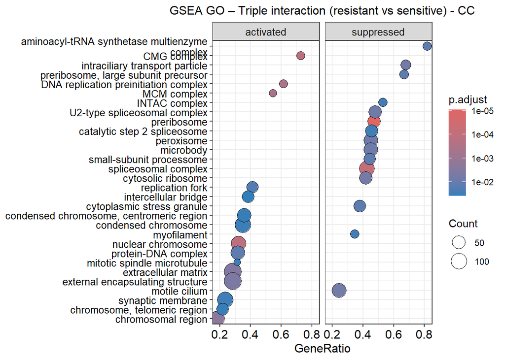

```r
plot_gsea_split(gse_cc, "CC", show = 15)
```

```
## MF: 10 activated, 13 suppressed
```

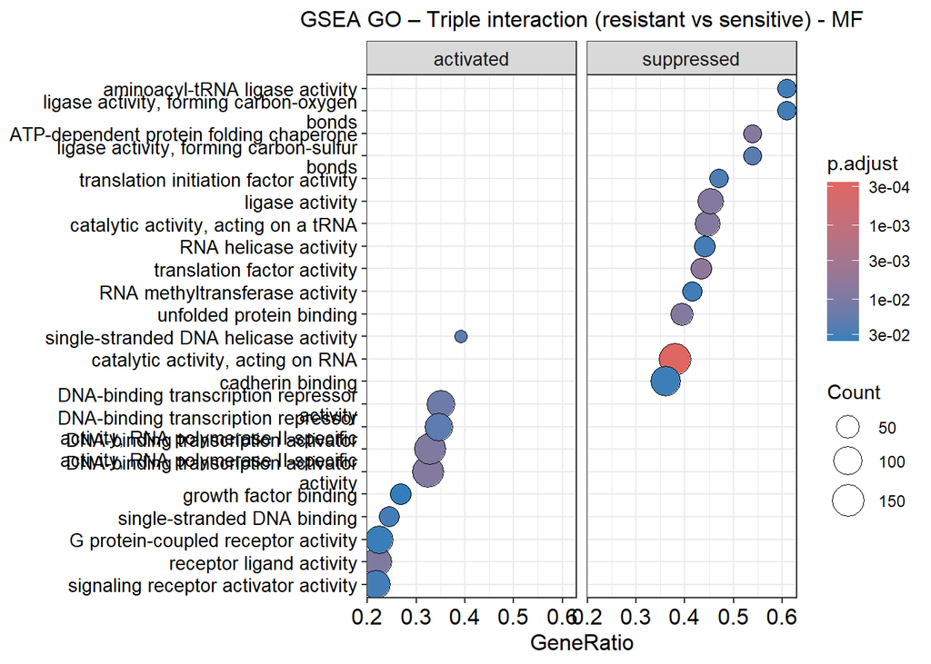

```r
plot_gsea_split(gse_mf, "MF", show = 15)
```

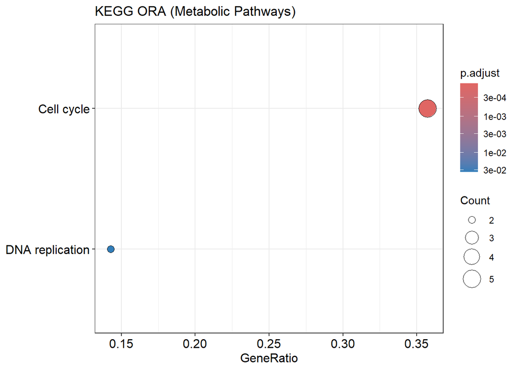

```r
# list of significant genes (symbols)
sig_genes <- rownames(res_int[!is.na(res_int$padj) & res_int$padj < 0.05, ])

# Entrez ID
sig_genes_entrez <- mapIds(org.Hs.eg.db, keys = sig_genes, keytype = "SYMBOL", column = "ENTREZID", multiVals = "first")
sig_genes_entrez <- na.omit(sig_genes_entrez)

# ORA по KEGG
kegg_ora <- enrichKEGG(gene = sig_genes_entrez, organism = 'hsa', pvalueCutoff = 0.05)

# Visualization
if (nrow(kegg_ora) > 0) {
  dotplot(kegg_ora, showCategory = 15) + ggtitle("KEGG ORA (Metabolic Pathways)")
} else {
  cat("No significant KEGG pathways found for ORA.\n")
}
```

```r
table(sign(gse_go$NES))
```

```
##
##  -1   1
##  67 170
```

On pathways

```r
dorothea_regulons <- dorothea::dorothea_hs %>%
    filter(confidence %in% c("A", "B", "C"))

head(dorothea_regulons)
```

```
## # A tibble: 6 × 4
##   tf    confidence target   mor
##   <chr> <chr>      <chr>  <dbl>
## 1 AHR   C          CYP1A1     1
## 2 AHR   C          CYP1A2     1
## 3 AHR   C          CYP1B1     1
## 4 AHR   C          FOS        1
## 5 AHR   C          MYC        1
## 6 AHR   C          UGT1A6     1
```

```r
vsd_matrix <- assay(vst(dds, blind = FALSE))
colnames(vsd_matrix) <- rownames(colData(dds))
vsd_matrix <- vsd_matrix[rowSums(vsd_matrix) > 0, ]

tf_activity <- decoupleR::run_mlm(
    mat = vsd_matrix,
    network = dorothea_regulons,
    .source = "tf",
    .target = "target",
    .mor = "mor"
)

tf_wide <- tf_activity %>%
    dplyr::select(source, condition, score) %>%
    tidyr::pivot_wider(names_from = source, values_from = score)
```

```r
heatmap_matrix <- as.matrix(tf_wide[, -1])
rownames(heatmap_matrix) <- tf_wide$condition


heatmap_matrix_t <- t(heatmap_matrix)

colnames(heatmap_matrix_t) <- rownames(metadata)

top_tf_vars <- names(sort(apply(heatmap_matrix_t, 1, var), decreasing = TRUE))[1:20]

heatmap_matrix_t_top <- heatmap_matrix_t[top_tf_vars, , drop = FALSE]

annotation_col <- data.frame(
  cell_line = metadata$cell_line,
  condition = metadata$condition,
  e1a_status = metadata$e1a_status,
  row.names = rownames(metadata)
)

ann_colors <- list(
  cell_line = setNames(c("#7CCD7C", "#CD8500"), unique(metadata$cell_line)),
  condition = setNames(c("#AB82FF", "#CD6090"), unique(metadata$condition)),
  e1a_status = setNames(c("#CCCCCC", "#CC9999"), unique(metadata$e1a_status))
)

pheatmap(heatmap_matrix_t_top,
         scale = "row",
         annotation_col = annotation_col,
         annotation_colors = ann_colors,
         labels_col = metadata$stat,
         cluster_cols = FALSE,
         main = "TF activity (mlm method, top 20 TFs)",
         angle_col = 45,
         fontsize_col = 8,
         filename = "TF_activity_heatmap.png",
         width = 12,
         height = 8,
         dpi = 300)
```

```r
genes_of_interest <- c("ITGB7", "MYH4", "NSUN5P1", "ARC", "CDT1", "DUSP1",
                       "E2F1", "H2AX", "KIFC1", "KLK11", "MCM5", "MCM7",
                       "MYBL2", "NRGN", "OAS3", "PKDCC", "SULF2", "TICRR",
                       "TONSL", "TREX1")


present <- genes_of_interest[genes_of_interest %in% rownames(dds)]
if(length(present) == 0) stop("None of the genes found")
cat("Found", length(present), "genes out of", length(genes_of_interest), "\n")
```

```
## Found 20 genes out of 20
```

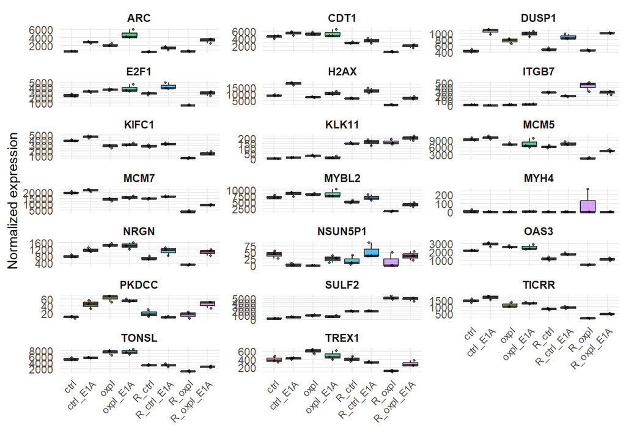

```r
norm_counts <- counts(dds, normalized = TRUE)

counts_subset <- norm_counts[present, , drop = FALSE]


df_long <- as.data.frame(t(counts_subset))
df_long$sample <- rownames(df_long)
df_long <- merge(df_long, metadata[, "stat", drop = FALSE], by.x = "sample", by.y = 0)
df_long <- df_long %>%
  pivot_longer(cols = all_of(present), names_to = "gene", values_to = "expression")

df_long$stat <- factor(df_long$stat, levels = c("ctrl", "ctrl_E1A", "oxpl", "oxpl_E1A",
                                                "R_ctrl", "R_ctrl_E1A", "R_oxpl", "R_oxpl_E1A"))

p <- ggplot(df_long, aes(x = stat, y = expression, fill = stat)) +
  geom_boxplot(outlier.shape = NA, alpha = 0.7) +
  geom_jitter(width = 0.2, size = 0.8, alpha = 0.6) +
  facet_wrap(~ gene, scales = "free_y", ncol = 3) +   # 3 колонки
  theme_minimal() +
  theme(axis.text.x = element_text(angle = 45, hjust = 1, size = 8),
        strip.text = element_text(face = "bold"),
        legend.position = "none") +
  labs(x = "", y = "Normalized expression")

print(p)
```

```r
ggsave("boxplots_selected_genes.png", plot = p, width = 14, height = 15, dpi = 600)
```

In the context of the triple interaction between resistant cells with E1A and oxaliplatin and sensitive cells with both E1A, we observe a decrease in ribosome biogenesis and RNA processing in the resistant cells. This is due to the negative NES (Gene Set Enrichment Analysis) for terms related to ribosomal biogenesis, RNA processing, etc., which is consistent with the overall pattern of gene regulation in these cells.

Since there is a list of genes that are regulated by E1A that are mainly involved in replication and repair, the general picture is that E1A activates genes associated with proliferation and repair (E2F1, CDT1, MCM, TONS, H2AX) in resistant cells, but suppresses the synthesis of ribosomes and overall translational activity.

This combination can create replicative stress and increase the dependence of cells on repair systems, which can potentially be used in therapy. This also explains why resistant cells become more sensitive to additional damage (for example, oxaliplatin) - they synthesize fewer ribosomes, cannot quickly increase protein synthesis for protection, but at the same time, intensively replicate DNA, leading to the accumulation of errors and apoptosis.